# Practical Machine Learning Course Project

Steven Johnson

Thursday, April 07, 2016

## Introduction

In the Weight Lifting Exercises Dataset, six participants performed a set of 10 repetitions of the Unilateral Dumbbell Biceps Curl while wearing 3 body sensors using a sensor-enabled dumbell. The exercise was done in one of 5 different fashions: exactly according to the specification (Class A), throwing the elbows to the front (Class B), lifting the dumbbell only halfway (Class C), lowering the dumbbell only halfway (Class D) and throwing the hips to the front (Class E). Data from this experiment has been made avaliable as training and testing datasets.

The goals of this course project are the following:

- Utilizing a machine learning approach, create a model using the training data capable of predicting activity class from sensor data.
- Use cross-validation and estimate the expected out of sample error of your approach.
- Create a report detailing data pre-processing, data partitioning, cross-validation, and model creation.
- Predict the activity class in the 20 sample testing data.

## Getting and Cleaning Data

Download the training data for this project.

```r
trainURL<-getURL("https://d396qusza40orc.cloudfront.net/predmachlearn/pml-training.csv", ssl.verifypeer=0L, followlocation=1L)
training<-read.csv(text=trainURL)
```

Download the test data used for the Prediction Quiz portion of the project.

```r
testURL<-getURL("https://d396qusza40orc.cloudfront.net/predmachlearn/pml-testing.csv", ssl.verifypeer=0L, followlocation=1L)
testing<-read.csv(text=testURL)
```

Remove training data columns with missing values, near zero variance, and extraneous columns.

```r
training<-training[,which(colSums(is.na(training))==0)]
training<-training[,-nearZeroVar(training)]
training<-training[,-c(1:6)]
```

This produces a training dataset with 19,622 observations on 52 different variables.

Now that we have eliminated multiple columns from the training data, modify the testing data columns to match. Of course, the exercise classification column, classe, in the training data is not included in the testset data.

```r
testing<-testing[,names(training[,-c(53)])]
```

Exploratory examination of the source files reveals that columns with matching names in the training and testing data do not always have the same type. e.g. numeric versus integer. To be safe, these should be standardized. Set the training column types to those in the testing data.

```r
for(i in 1:dim(training[,-c(53)])[2]){
  class(training[,i])<-class(testing[,i])
}
```

## Partitioning Data

In order to estimate the out of sample error, the training data was further partitioned into training(75%) and testing(25%) 4-fold cross-validation sets(A-D). The choice of k was based on practical time limitations. Smaller values of k have the effect of increasing bias but producing less variance. Ideally, a higher value of k would be chosen however given the time taken to train on each of these training sets, discussed below, k=4 was chosen.

```r
set.seed(1234)
foldsT<-createFolds(y=training$classe, k=4, list=TRUE, returnTrain = TRUE)
foldsV<-createFolds(y=training$classe, k=4, list=TRUE, returnTrain = FALSE)
```

## Model Creation

Due to excellent performance as a general machine learning classifier, random forest was chosen as the machine learning algorithm. Random forest models were trained on each of the 4-fold cross validation training sets. Since the creation of each of these models is time consuming, ~7 hours each, the models were saved and used in later analysis stages.

```r
set.seed(7654)
modFitRFa<-train(classe~., data=training[foldsT[[1]],], method="rf", prox=TRUE)
save(modFitRFa, file="modFitRFa.rDA")
rm(modFitRFa)

modFitRFb<-train(classe~., data=training[foldsT[[2]],], method="rf", prox=TRUE)
save(modFitRFb, file="modFitRFb.rDA")
rm(modFitRFb)

modFitRFc<-train(classe~., data=training[foldsT[[3]],], method="rf", prox=TRUE)
save(modFitRFc, file="modFitRFc.rDA")
rm(modFitRFc)

modFitRFd<-train(classe~., data=training[foldsT[[4]],], method="rf", prox=TRUE)
save(modFitRFd, file="modFitRFd.rDA")
rm(modFitRFd)
```

Each of these trainings created 500 trees and explored tuning paramaters such as the number of predictors to randomly sample at each node, mtry.

```r
load("modFitRFa.rDA")
modFitRFa
```

```
## Random Forest
##
## 14716 samples
##    52 predictor
##     5 classes: 'A', 'B', 'C', 'D', 'E'
##
## No pre-processing
## Resampling: Bootstrapped (25 reps)
## Summary of sample sizes: 14716, 14716, 14716, 14716, 14716, 14716, ...
## Resampling results across tuning parameters:
##
##   mtry  Accuracy   Kappa      Accuracy SD  Kappa SD
##    2    0.9886628  0.9856567  0.001729233  0.002191114
##   27    0.9886589  0.9856528  0.001983368  0.002510526
##   52    0.9792963  0.9738078  0.005209224  0.006588283
##
## Accuracy was used to select the optimal model using  the largest value.
## The final value used for the model was mtry = 2.
```

The final models used mtry=2, 27, 27, and 2 for training sets A-D.

Training data variable importance for the random forest model trained on one of the 4-fold cross validated training sets is as follows:

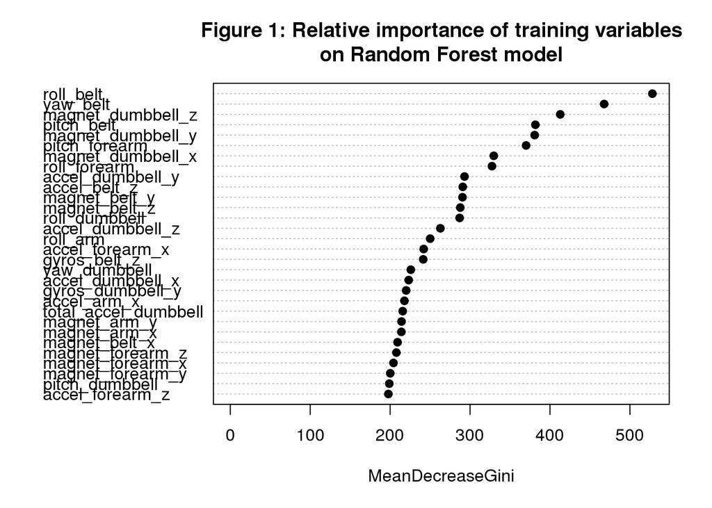

```r
varImpPlot(modFitRFa$finalModel, main="Figure 1: Relative importance of training variables\non Random Forest model", pch=19)
```

This plot shows the mean decrease in Gini coefficient, which is a measure of how much each variable contributes to node homogeneity or purity, with the “roll belt” and “yaw belt” variables having the two highest importance.

We can assess the performance of the models on the 4 validation sets(A-D) created from the original training data.

```r
load("modFitRFa.rDA")
predRF1<-predict(modFitRFa, training[foldsV[[1]],])
rm(modFitRFa)

load("modFitRFb.rDA")
predRF2<-predict(modFitRFb, training[foldsV[[2]],])
rm(modFitRFb)

load("modFitRFc.rDA")
predRF3<-predict(modFitRFc, training[foldsV[[3]],])
rm(modFitRFc)

load("modFitRFd.rDA")
predRF4<-predict(modFitRFd, training[foldsV[[4]],])
rm(modFitRFd)
```

We can generate a table of the predictions to the actual activity class from each of the validation sets. Below are the results from validation set A.

```r
confusionMatrix(predRF1, training[foldsV[[1]],c("classe")])$table
```

```
##           Reference
## Prediction    A    B    C    D    E
##          A 1394    1    0    0    0
##          B    1  947    3    0    0
##          C    0    1  853    1    0
##          D    0    0    0  803    0
##          E    0    0    0    0  902
```

We can also calculate the accuracy and out of set error rates for each of the validation sets.

Table 1: Accuracy and Error Rates of Cross-Validated Models

| ValidationSet | Accuracy | Error |
| --- | --- | --- |
| 1 | 0.9985732 | 0.0014268 |
| 2 | 0.9989806 | 0.0010194 |
| 3 | 0.9985729 | 0.0014271 |
| 4 | 0.9987770 | 0.0012230 |

The mean accuracy and out of set error rate are 0.9987259 and 0.0012741, respectively.

## Prediction of Testing Data Activity Class

Originally, I had planned to run each of the 4 random forest models trained on each of the cross-validated datasets on the predicition testing set and combine the predictions. Alternatively, I thought I might train a new model on the full training dataset. However, this ended up not being necessary. Each of the four models had very high, and similar, accuracies on the validation sets. Therefore, it was not surprising that each of the four models gave the same set of predictions. Given their agreement, I decided to submit the predictions. Given this gave 20/20 correct, I decided to not create a model on the full dataset.

```r
library(knitr)
df<-data.frame(rbind(as.character(pred1), as.character(pred2),
                     as.character(pred3), as.character(pred4)))
names(df)<-c(1:20)
row.names(df)<-c("Pred1", "Pred2", "Pred3", "Pred4")
kable(df, caption = "Table 2: Model Predictions on Testing Data")
```

Table 2: Model Predictions on Testing Data

|  | 1 | 2 | 3 | 4 | 5 | 6 | 7 | 8 | 9 | 10 | 11 | 12 | 13 | 14 | 15 | 16 | 17 | 18 | 19 | 20 |
| --- | --- | --- | --- | --- | --- | --- | --- | --- | --- | --- | --- | --- | --- | --- | --- | --- | --- | --- | --- | --- |
| Pred1 | B | A | B | A | A | E | D | B | A | A | B | C | B | A | E | E | A | B | B | B |
| Pred2 | B | A | B | A | A | E | D | B | A | A | B | C | B | A | E | E | A | B | B | B |
| Pred3 | B | A | B | A | A | E | D | B | A | A | B | C | B | A | E | E | A | B | B | B |
| Pred4 | B | A | B | A | A | E | D | B | A | A | B | C | B | A | E | E | A | B | B | B |